# Examen_2022_AnaMatamoros

Ana Matamoros

1/31/2022

### 1. Comandos Linux: Tengo un fichero llamado genes.txt con 3 columnas: Nombre_ de_ gen, cromosoma y posición. Separados por tabulados. ¿Qué comando utilizarías para saber?:

cat genes.txt

### 1.a) ¿Cuántas palabras hay en el fichero?

wc genes.txt

### 1.b) ¿Cómo cambiarías todos los tabulados por guiones?

Cat genes.txt | sed ‘s/-/g’

### 1.c) ¿Cómo cambiarías solo la primera aparición?

Cat genes.txt | sed ‘s/-/1’ | awk ’{print$1}

### 1.d. ¿Cómo buscarías todos los genes excepto el gen llamado DSTYK?

Cat genes.txt | wc | grep -v DSTYK

### 2)

```r
#install.packages("nycflights13")
library("nycflights13")
#install.packages("dplyr")
library("dplyr")
weather <- nycflights13::weather
delete.na <- function(df, n=0) {
  df[rowSums(is.na(df)) <= n,]
}

weather_NA <- delete.na(weather)
```

### 2.a. (0.5 puntos) ¿Cuántas columnas y cuántos registros tiene este dataset?

```r
ncol(weather) #15
```

```
## [1] 15
```

```r
nrow(weather) #26115
```

```
## [1] 26115
```

### 2.b. (0.5 puntos) ¿Cuántos “origin” diferentes existen y para cada uno de ellos cuántos registros hay?

```r
table(weather$origin)
```

```
##
##  EWR  JFK  LGA
## 8703 8706 8706
```

```r
EWR_ <- weather[weather$origin == "EWR", ]
JFK_ <- weather[weather$origin == "JFK", ]
LGA_ <- weather[weather$origin == "LGA", ]
nrow(EWR_) #8703
```

```
## [1] 8703
```

```r
nrow(JFK_) #8706
```

```
## [1] 8706
```

```r
nrow(LGA_) #8706
```

```
## [1] 8706
```

### 2.c. (0.5 puntos) En LGA, ¿cuáles fueron la mediana del wind_speed y media de pressure?

```r
LGA_NA <- delete.na(LGA_)
median(LGA_NA$wind_speed) #16.11
```

```
## [1] 16.11092
```

```r
mean(LGA_NA$pressure) #1015
```

```
## [1] 1015.626
```

### 2.d. (0.5 puntos) Después de eliminar los NA de la columna wind_gust, calcula para cada mes la media de wind_speed y wind_gust, y el número de casos.

```r
weather%>%
     filter(!is.na(wind_gust))%>%
     group_by(month)%>%
     summarise(
         speed=mean(wind_speed),
         gust=mean(wind_gust),
         num=n()
     )
```

```
## # A tibble: 12 × 4
##    month speed  gust   num
##    <int> <dbl> <dbl> <int>
##  1     1  18.4  27.5   535
##  2     2  19.4  28.2   612
##  3     3  17.7  26.2   795
##  4     4  17.1  25.6   582
##  5     5  16.6  25.0   352
##  6     6  15.4  23.4   436
##  7     7  13.6  21.4   253
##  8     8  14.2  21.9   221
##  9     9  14.5  22.3   265
## 10    10  15.9  23.8   338
## 11    11  18.5  27.6   622
## 12    12  16.1  24.4   326
```

### 3.a) Intenta hacer este plot

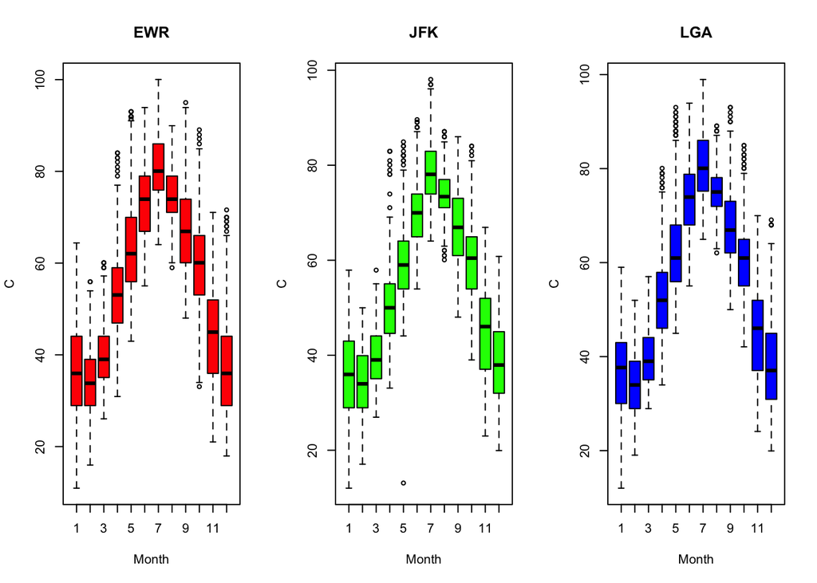

```r
par(mfrow = c(1, 3))
boxplot( data = EWR_,
temp~month,
main="EWR",
xlab="Month",
ylab="C",
col="red",
border="black"
)

boxplot (data = JFK_,
temp~month,
main = "JFK",
xlab = "Month",
ylab = "C",
col = "green",
border = "black")

boxplot (data = LGA_,
temp~month,
main = "LGA",
xlab = "Month",
ylab = "C",
col = "blue",
border = "black")
```

### 3.b) Crea una función que plotee el plot anterior.

- Como argumentos se podrán introducir: el nombre de la columna de interés, el título y las unidades.
- La función debe devolver un vector con 3 valores. Estos valores serán la media de cada uno de los lugares.
- Por pantalla también tendrá que aparecer la media mediante un print.

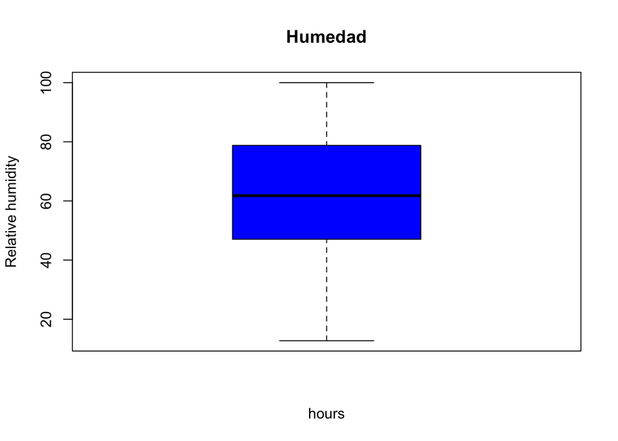

```r
plot_meteo <- function(dat = weather, meteo = "temp", titulo = "Punto de rocío", unidades = "F")
{
dat <- data.frame(dat)
boxplot (dat[,meteo], main = titulo, ylab = unidades, xlab = "hours", col = "blue" )
}

par(mfrow = c(1, 1))
plot_meteo(meteo = "humid", titulo = "Humedad", unidades = "Relative humidity")
```

### 4.a Qué correlación tuvieron la temperatura y humedad en cada uno de los origin? Plotealo mediante puntos con ggplot.

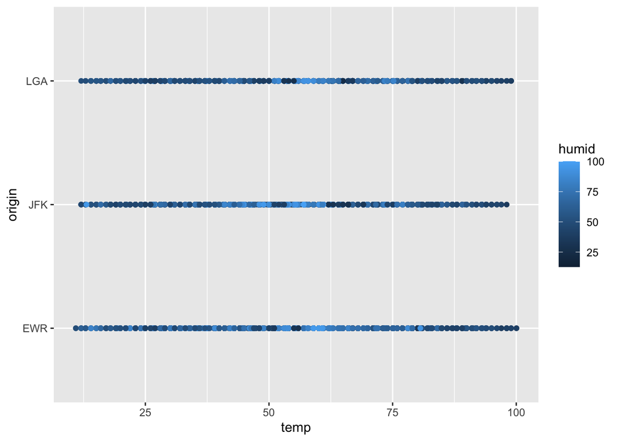

```r
#install.packages("ggplot2")
library("ggplot2")
ggplot(data = weather) +
geom_point(mapping = aes(x = temp, y = origin, col = humid))
```

### 4.b. Si comparas la temperatura en los origins JFK y LGA ¿son estadísticamente diferentes? ¿Qué p-valor consigues? Plotea los boxplots.

```r
t.test(log(JFK_$temp), log(LGA_$temp))
```

```
##
##  Welch Two Sample t-test
##
## data:  log(JFK_$temp) and log(LGA_$temp)
## t = -3.9221, df = 17403, p-value = 8.811e-05
## alternative hypothesis: true difference in means is not equal to 0
## 95 percent confidence interval:
##  -0.03128871 -0.01043633
## sample estimates:
## mean of x mean of y
##  3.942053  3.962916
```

##### El p-valor es mucho menor que 0.05 por lo que se podria concluir que las temperaturas entre los origenes si son estadisticamente diferentes.

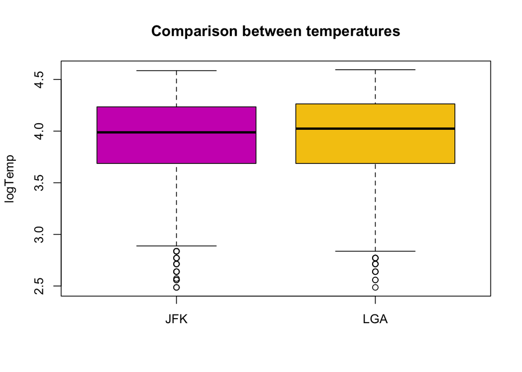

```r
boxplot(log(JFK_$temp), log(LGA_$temp), col = 6:7, names = c("JFK", "LGA"), ylab = "logTemp", main = "Comparison between temperatures")
```

### 6. Sube el examen a github y escribe a continuación tu url aquí.

https://github.com/AnaLMD/ExamenBioinformatica_2022_ALMD.git